# DAM AT1 Part A

Joshua McCarthy

```r
install.packages(tidyverse)
```

```r
library(tidyverse)
```

# 1. EDA

## a. Do you need to clean the data in any way? Justify what you decide to do (or not do).

### what do we do?

provide financial services to a number of clients, each client working in a specified industry group, and in a specified location group. Clients are billed monthly.

### Data

```r
transactions <- read_csv("transactions.csv")
names(transactions)
```

```
## [1] "date"           "customer_id"    "industry"       "location"
## [5] "monthly_amount"
```

```r
str(transactions)
```

```
## Classes 'spec_tbl_df', 'tbl_df', 'tbl' and 'data.frame': 94248 obs. of  5 variables:
##  $ date          : chr  "1/1/13" "1/2/13" "1/3/13" "1/4/13" ...
##  $ customer_id   : chr  "70efdf2ec9b086079795c442636b55fb" "70efdf2ec9b086079795c442636b55fb" "70efdf2ec9b086079795c442636b55fb" "70efdf2ec9b086079795c442636b55fb" ...
##  $ industry      : num  8 8 8 8 8 8 8 8 8 8 ...
##  $ location      : num  9 9 9 9 9 9 9 9 9 9 ...
##  $ monthly_amount: num  753851 651548 1138769 659739 770675 ...
##  - attr(*, "spec")=
##   .. cols(
##   ..   date = col_character(),
##   ..   customer_id = col_character(),
##   ..   industry = col_double(),
##   ..   location = col_double(),
##   ..   monthly_amount = col_double()
##   .. )
```

```r
summary(transactions)
```

```
##      date           customer_id           industry         location
##  Length:94248       Length:94248       Min.   : 1.000   Min.   : 1.000
##  Class :character   Class :character   1st Qu.: 1.000   1st Qu.: 2.000
##  Mode  :character   Mode  :character   Median : 2.000   Median : 4.000
##                                        Mean   : 2.455   Mean   : 4.214
##                                        3rd Qu.: 3.000   3rd Qu.: 6.000
##                                        Max.   :10.000   Max.   :10.000
##  monthly_amount
##  Min.   :        0
##  1st Qu.:    95323
##  Median :   179399
##  Mean   :   395397
##  3rd Qu.:   375439
##  Max.   :100000000
```

```r
range(transactions$date) # range doesn't work on dates?
```

```
## [1] "1/1/13" "1/9/16"
```

```r
sapply(transactions, function(x) length(unique(x))) #number of unique entries for each variable
```

```
##           date    customer_id       industry       location monthly_amount
##             47           4464             10             10          82525
```

*Transactions don’t have unique identifiers (no primary key), relies on composite keys date + customer* Are there any NA’s"?

```r
nrow(transactions) == nrow(na.omit(transactions))
```

```
## [1] TRUE
```

```r
# A. No
```

#### date - Date of the first day of each month

##### Top level info

- Transaction period 1/1/2013 - 1/9/2016 (see below, actual range - 01/11/2016) ** Period of 45 months inclusive (actual 47 months inclusive)

##### Changes to make

- As character -> as posix? / date

```r
transactions$date <- as.Date(transactions$date, format = "%d/%m/%Y")
range(transactions$date) # range doesn't work on dates?
```

```
## [1] "13-01-01" "16-11-01"
```

```r
# date was being read incorrectly
```

##### Questions

- All customer have equal number of transactions over the full period?

```r
number_of_transactions_per_customer <- as.data.frame(table(transactions$customer_id))
head(number_of_transactions_per_customer)
```

```
##                               Var1 Freq
## 1 000a91f3e374e6147d58ed1814247508    8
## 2 0014fcb3db4c8459d26309b177005b10   14
## 3 0023a1e3447fdb31836536cc903f1310   47
## 4 0023daa5a44ef6fbe42379f24e00254c   32
## 5 0029f088c57ad3b6ec589f9ba4f7a057    4
## 6 003af5a042e00ac9b489153a81d676ca    8
```

```r
# A. no
```

- Do any customers have more than one transaction for the same date?

```r
# ggplot(transactions, aes(y = customer_id, x= date)) + geom_point(alpha = 0.25)
# too much data for small area

transactions$duplicated <- transactions %>%
  select(date, customer_id) %>%
  duplicated()

transactions %>%
  filter(duplicated == "TRUE")
```

```
## # A tibble: 0 x 6
## # … with 6 variables: date <date>, customer_id <chr>, industry <dbl>,
## #   location <dbl>, monthly_amount <dbl>, duplicated <lgl>
```

```r
#A. No.
```

```r
transactions <- transactions %>%
  select(-duplicated)
```

- Why are there 47 dates in a 45 month range? The range function was not reading the date as character data correctly
- Breaks in customer relationship?

#### customer_id - Unique customer identifier

##### Top level info

- Hashed customer ID’s

##### Changes to make

- to factors

```r
transactions$customer_id <- as.factor(transactions$customer_id)
```

##### Questions

- How many unique customers?

```r
# table(transactions$customer_id)
# Alot

length(unique(transactions$customer_id))
```

```
## [1] 4464
```

#### industry - Code for 10 industries, ranging from 1 to 10

##### Top level info

- x

##### Changes to make

- To factors

```r
transactions$industry <- as.factor(transactions$industry)
```

##### Questions

- Are all industries represented?

```r
unique(transactions$industry)
```

```
##  [1] 8  1  9  10 2  5  4  6  7  3
## Levels: 1 2 3 4 5 6 7 8 9 10
```

```r
#A. Yes
```

- Do all customers only operate in one industry?

```r
# transactions$multi_industry <-

industry_check <- transactions %>%
  select(industry, customer_id) %>%
  distinct()

industry_check$multi_industry <- industry_check %>%
  select(customer_id) %>%
  duplicated()

industry_check %>%
  filter(multi_industry == "TRUE")
```

```
## # A tibble: 0 x 3
## # … with 3 variables: industry <fct>, customer_id <fct>, multi_industry <lgl>
```

```r
# A. Yes
```

- Distribution between industries?

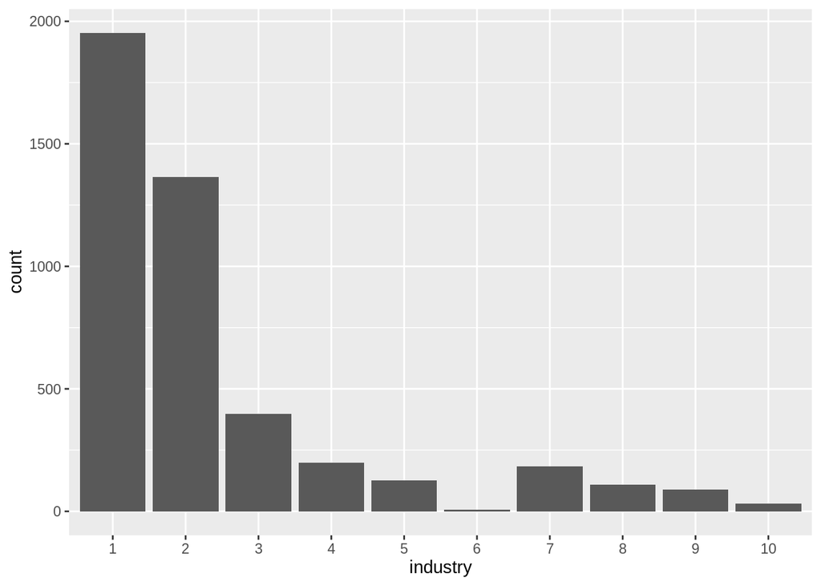

```r
transactions %>%
  distinct(customer_id, industry) %>%
ggplot(aes(x = industry)) + geom_bar()
```

** low participation in industry 6 and 10

```r
customers_industry_6 <- transactions %>%
  distinct(customer_id, industry) %>%
  filter(industry == 6)

count(customers_industry_6)
```

```
## # A tibble: 1 x 1
##       n
##   <int>
## 1     7
```

```r
customers_industry_10 <- transactions %>%
  distinct(customer_id, industry) %>%
  filter(industry == 10)

count(customers_industry_10)
```

```
## # A tibble: 1 x 1
##       n
##   <int>
## 1    32
```

```r
#A. Both still significant, even though under represented
```

#### location - Code for 10 industries, ranging from 1 to 10

##### Top level info

- x

##### Changes to make

- To factors

```r
transactions$location <- as.factor(transactions$location)
```

##### Questions

- Are all locations represented?

```r
unique(transactions$location)
```

```
##  [1] 9  4  2  5  10 6  1  3  8  7
## Levels: 1 2 3 4 5 6 7 8 9 10
```

```r
# A. Yes
```

- Do all customers only operate in one location?

```r
location_check <- transactions %>%
  select(location, customer_id) %>%
  distinct()

location_check$multi_location <- location_check %>%
  select(customer_id) %>%
  duplicated()

location_check %>%
  filter(multi_location == "TRUE")
```

```
## # A tibble: 0 x 3
## # … with 3 variables: location <fct>, customer_id <fct>, multi_location <lgl>
```

```r
# A. Yes
```

- Customer distribution between locations?

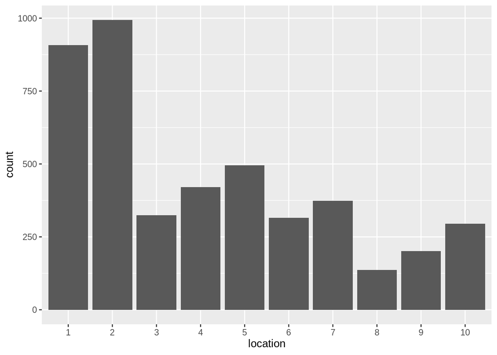

```r
transactions %>%
  distinct(customer_id, location) %>%
ggplot(aes(x = location)) + geom_bar()
```

#### monthly_amount - Total transaction amount for customer in given month

##### Top level info

- Range from 0 to 100,000,000
- Median 179399
- Mean 395397

##### Changes to make

- x

##### Questions

- Why are there transactions worth 0? ** How many transactions worth 0?
- Why are there transactions worth 100,000,000 ** How many transactions are worth 100,000,000 ** Is this an arbitrary value?
- Does most business fall within a certain range?
- What is the distribution of transactions?
- Are any fees “standard” ** Are they from the same customer?
- What is each customers total spend?

#### Exploration plots

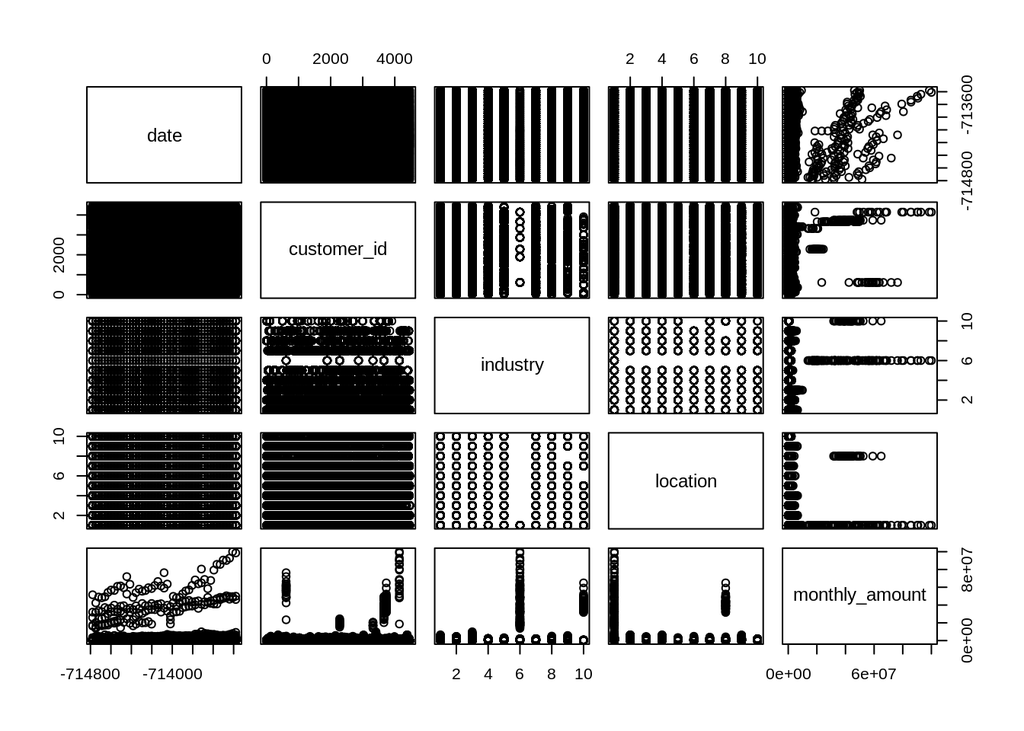

```r
plot(transactions)
```